## Jak postrzegamy wykresy kołowe?

Bartosz Topolski

# Wykresy kołowe

[figure not shown]

[figure not shown]

# Cel artykułu

Celem autorów było zbadanie tego, które z trzech czynników mają decydujący wpływ na postrzeganie wykresów kołowych. W tym celu grupie około 100 osób pokazane zostały wykresy kołowe zubożone (lub wzbogacone) o niektóre aspekty. Każdy miał ocenić jakie odsetki prezentuje dany wykres.  
W celu porównania wyników autorzy przeprowadzili graficzną analizę otrzymanych średnich dla każdego typu wykresu opartą o przedziały ufności.

Wyniki były oparte o średni błąd oraz o średni błąd bezwzględny. Dzięki temu możemy sprawdzić zarówno zdolność do przekłamywania danego typu wykresu, jak i trudność odczytania.

# Długość łuku, kąt czy powierzchnia?

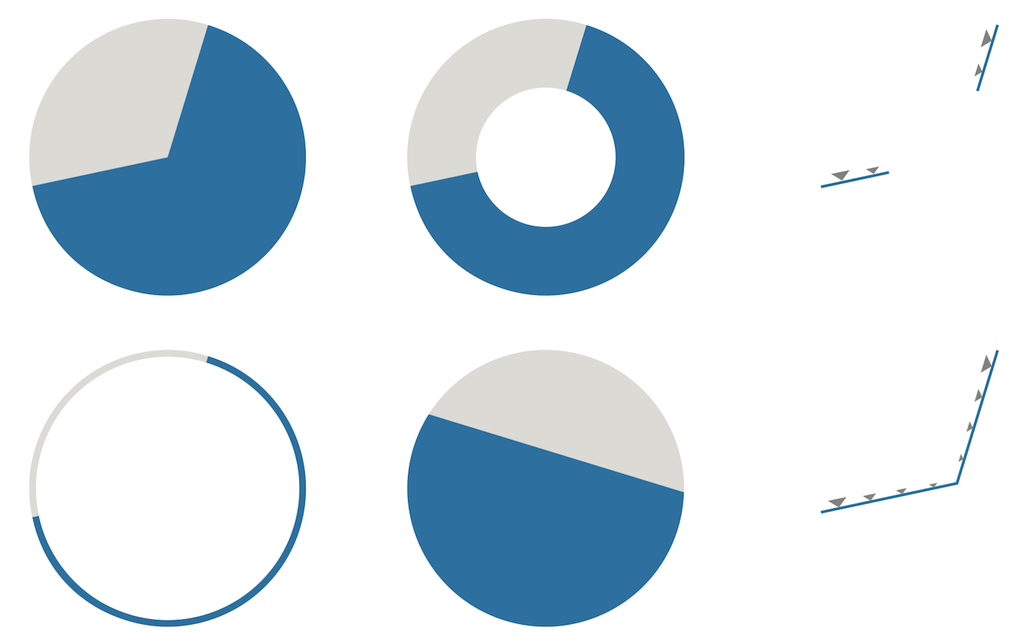

#### Wyniki (średni błąd)

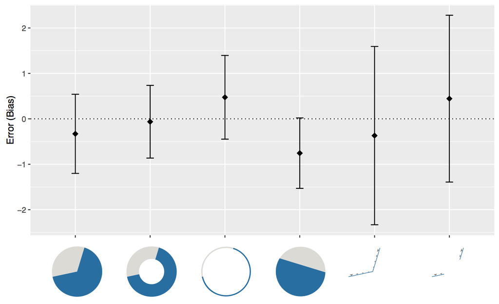

#### Wyniki (średni błąd)

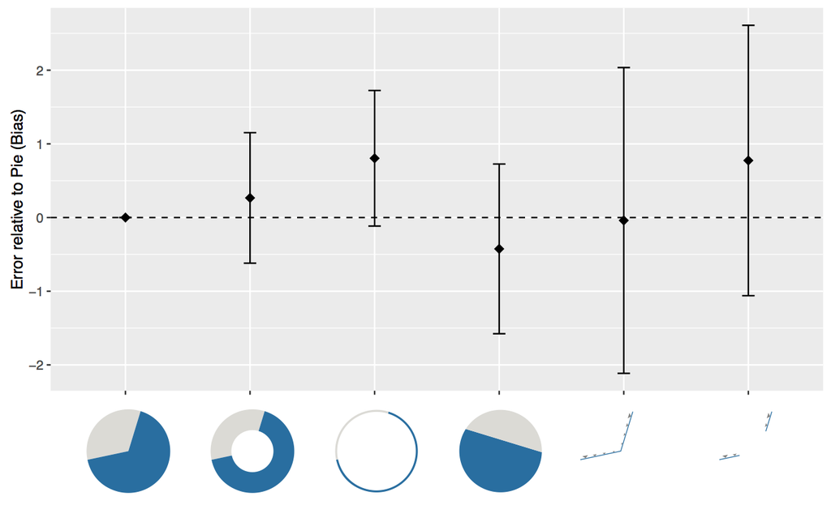

#### Wyniki (średni błąd bezwzględny)

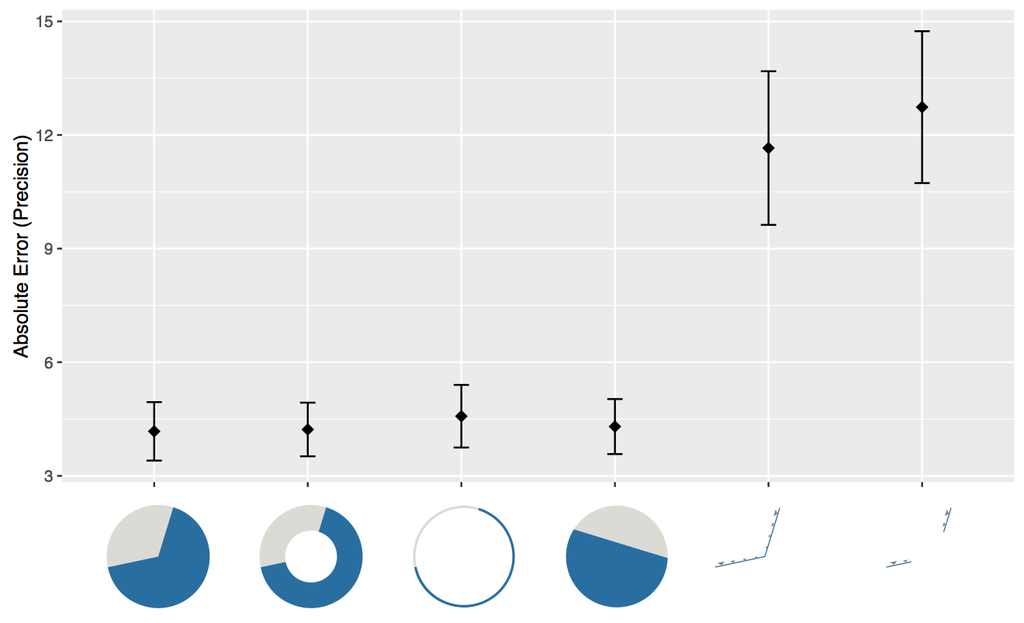

#### Wyniki (średni błąd bezwzględny)

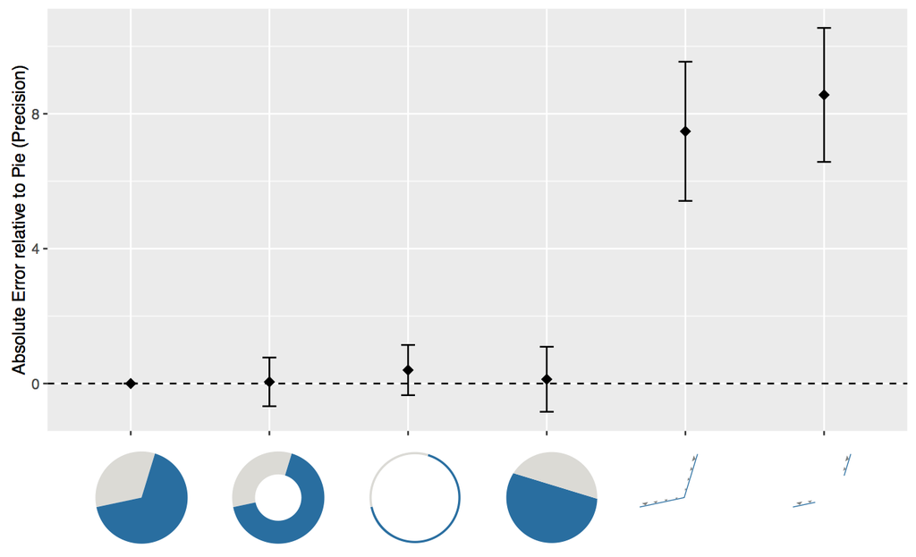

#### Wnioski

- żaden z “obciętych” wykresów nie wskazywał tendencji do nadmiernego przekłamywania wyników,
- pozostawienie informacji tylko o kącie powoduje dużo większe błędy przy odczytywaniu wykresu - może to wskazywać na to, że nie postrzegamy wykresów kołowych przez pryzmat kątów.

# Długość wewnętrznego promienia

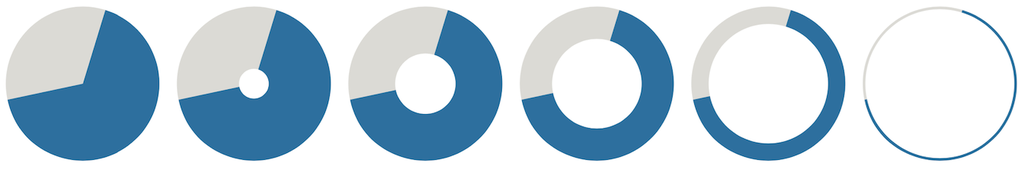

#### Wyniki (średni błąd)

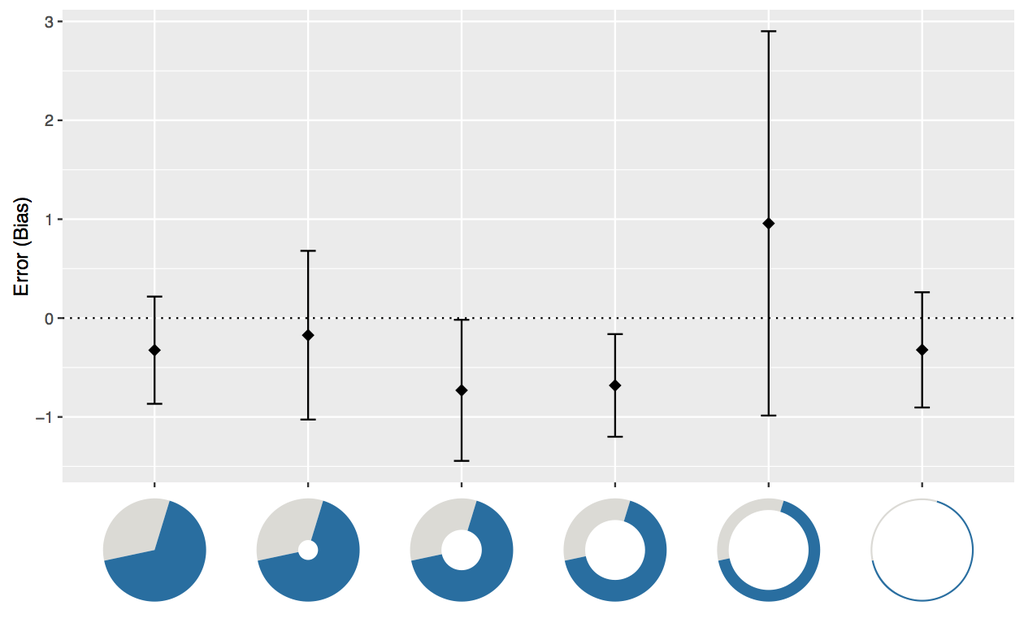

#### Wyniki (średni błąd)

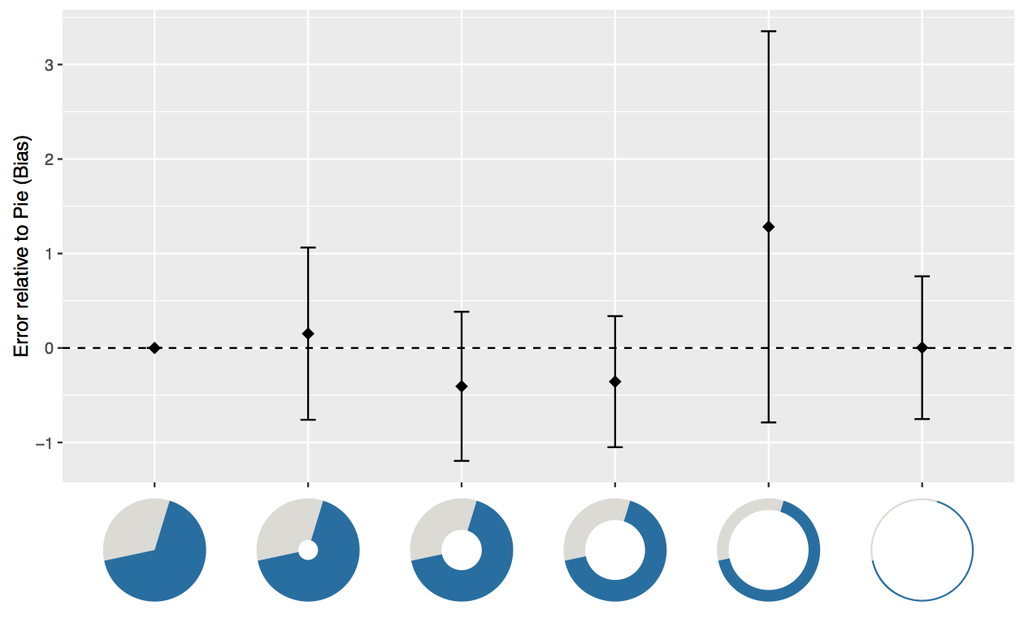

#### Wyniki (średni błąd bezwzględny)

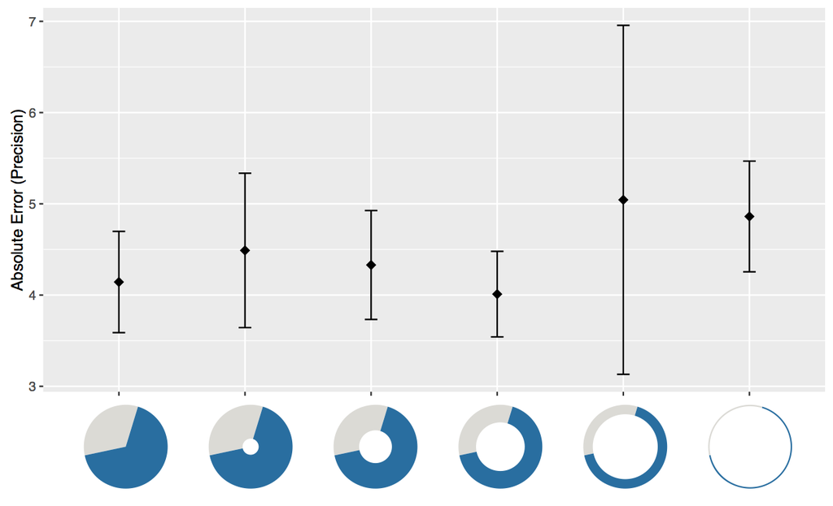

#### Wyniki (średni błąd bezwzględny)

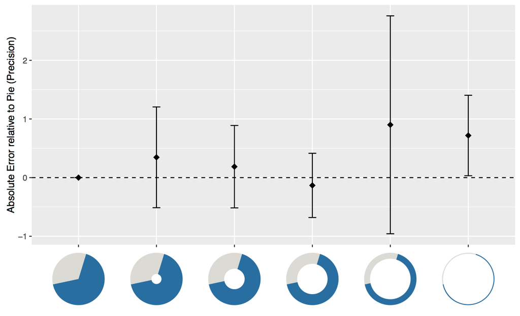

#### Wnioski

- w tym porównaniu nie widać istotnych statystycznie różnic między poszczególnymi wykresami,
- jedynie ostatni typ pokazał różnicę która jest na granicy istotności, jednak autorzy podejrzewają że wynika to z dośc małej ilości próbki,
- wyniki pasują do tych uzyskanych w poprzednim teście - wycięcie środkowej części kąta nie powoduje istotnej zmiany w postrzeganiu wykresu.

# Różne typy wykresów

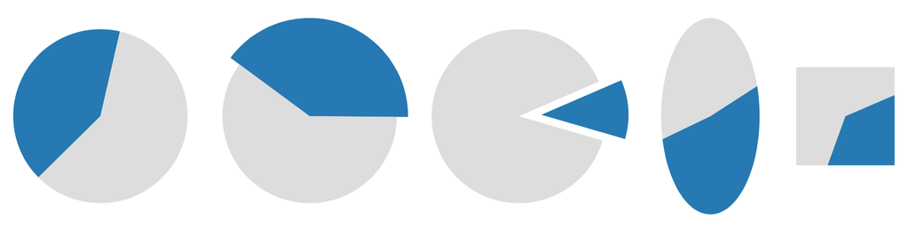

#### Wyniki (średni błąd)

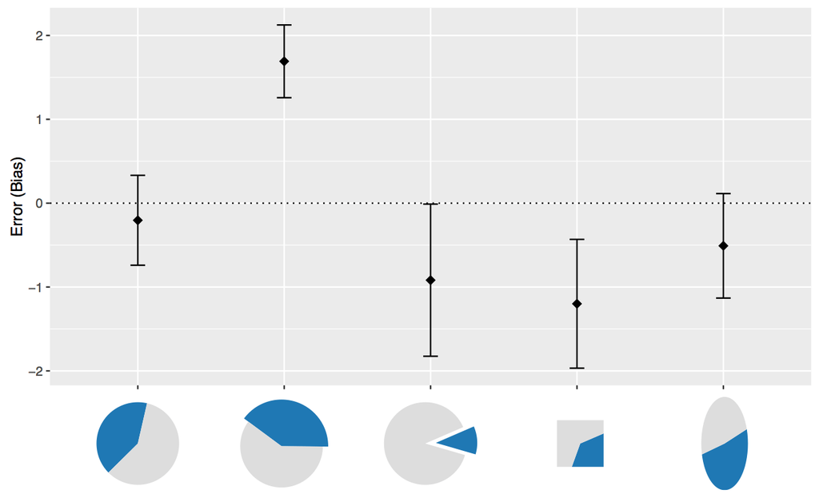

#### Wyniki (średni błąd)

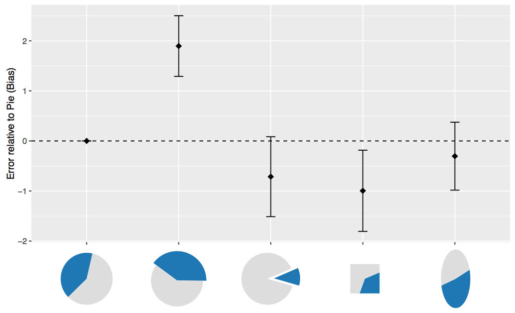

#### Wyniki (średni błąd bezwzględny)

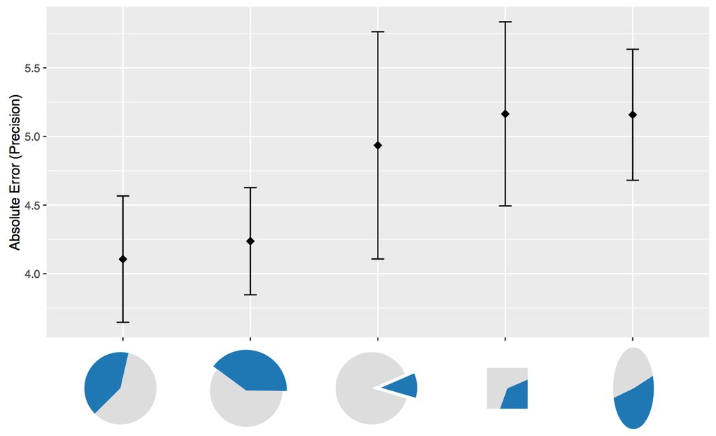

#### Wyniki (średni błąd bezwzględny)

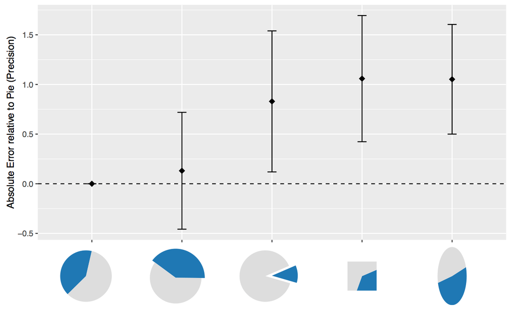

#### Wnioski

- powiększenie jednej z części wykresu powoduje spore przekłamanie w odbieranych wynikach, co wskazuje na to, że kąt może być mniej ważny niż powierzchnia i długość łuku,
- użycie wykresów nieregularnych (kwadrat, owal) spowodowało większą rozbieżność w otrzymanch szacowaniach. Warto zauważyć, że dla tych wykresów tracimy liniową zależność między długością “łuku” a polem powierzchni.

# Podsumowanie

Otrzymane wyniki wskazują na to, że wykresy kołowe nie są odczytywane przez pryzmat kątów, i największą rolę pełni pole powierzchni oraz długośc łuku. Ciężko jednak jednoznacznie wskazać który z tych czynników jest ważniejszy.  
Ciekawym wnioskiem jest też to, że wbrew popularnej opinii wykresy “donutowe” wcale nie są gorsze niż wykresy kołowe.  
Autorzy zostawiają otwartą kwestię użyteczności wykresów kołowych względem innych typów (na przykład słupkowych). Warto jednak zauważyć, że wykresy słupkowe pozwalają na dużo łatwiejsze porównanie powierzchni i długości niż wykresy kołowe.